# Casal2 Test Case MPD comparisons for SCI

# 1 SCI comparison of CASAL and Casal2 model configurations

This document compares the results of at least 2 CASAL model configurations (base and at least one sensitivity) and up to 6 Casal2 model configurations (3 BetaDiff and 3 ADOL-C).

The CASAL model sensitivity 1 has a smaller minimisation tolerance value than the CASAL base model (1e-8 vs. 2e-6).

## 1.1 SCI model characteristics

The main characteristics of the Test Case SCI (Scampi) CASAL model are:

- length-based sex-specific model
- years 1986 - 2022, projection years 2023 - 2027
- three time steps, Oct - Jan, Feb - Apr, May - Sep
- estimate growth transition matrix
- dour tag releases
- Beverton-Holt stock-recruitment relationship, with steepness (h) 0.75 and $CV_R$ 0.7 (prior)
- length-weight relationship ($W = aL^b$)
- three fisheries

Observation data include:

- trawl fishery CPUE
- trawl survey abundance and proportions-at-length
- fishery proportions-at-length
- tag-recapture data for growth estimation
- maturity data

Parameters estimated include:

- B0
- sex-specific growth parameters
- maturity parameters
- YCS (recruitment deviations)
- sex-specific fishery and trawl selectivity parameters

## 1.3 CASAL and Casal2 model output

```r
source('../../R-functions/report_read_in_CASAL_MPD_files.R')
```

```r
source('../../R-functions/report_read_in_Casal2_MPD_files.R')
```

## 1.4 Tables

Tables of parameter estimates and objective function components for the CASAL and Casal2 model MPD results

CASAL parameter estimates

| rownames | Base_Model | Sensitivity_1 | Percent_Diff |
| --- | --- | --- | --- |
| initialization.B0 | 2106.00000 | 2106.00000 | 0.000 |
| growth[1].minsigma_male | 4.51900 | 4.51900 | 0.000 |
| recruitment.YCS1 | 0.26100 | 0.26100 | 0.000 |
| recruitment.YCS2 | 0.28190 | 0.28190 | 0.000 |
| recruitment.YCS3 | 0.35370 | 0.35370 | 0.000 |
| recruitment.YCS4 | 0.54940 | 0.54940 | 0.000 |
| recruitment.YCS5 | 3.08000 | 3.08000 | 0.000 |
| recruitment.YCS6 | 0.61570 | 0.61570 | 0.000 |
| recruitment.YCS7 | 0.60020 | 0.60020 | 0.000 |
| recruitment.YCS8 | 0.50630 | 0.50630 | 0.000 |
| recruitment.YCS9 | 0.31460 | 0.31460 | 0.000 |
| recruitment.YCS10 | 0.38550 | 0.38550 | 0.000 |
| recruitment.YCS11 | 0.39680 | 0.39680 | 0.000 |
| recruitment.YCS12 | 0.37270 | 0.37270 | 0.000 |
| recruitment.YCS13 | 0.49890 | 0.49890 | 0.000 |
| recruitment.YCS14 | 0.37530 | 0.37530 | 0.000 |
| recruitment.YCS15 | 0.49940 | 0.49940 | 0.000 |
| recruitment.YCS16 | 0.53520 | 0.53520 | 0.000 |
| recruitment.YCS17 | 0.59340 | 0.59340 | 0.000 |
| recruitment.YCS18 | 0.36560 | 0.36560 | 0.000 |
| recruitment.YCS19 | 0.59920 | 0.59920 | 0.000 |
| recruitment.YCS20 | 0.46420 | 0.46420 | 0.000 |
| recruitment.YCS21 | 0.49390 | 0.49390 | 0.000 |
| recruitment.YCS22 | 0.55130 | 0.55130 | 0.000 |
| recruitment.YCS23 | 0.98750 | 0.98750 | 0.000 |
| recruitment.YCS24 | 0.53080 | 0.53080 | 0.000 |
| recruitment.YCS25 | 0.88540 | 0.88540 | 0.000 |
| recruitment.YCS26 | 0.91310 | 0.91310 | 0.000 |
| recruitment.YCS27 | 0.51160 | 0.51160 | 0.000 |
| recruitment.YCS28 | 0.64290 | 0.64290 | 0.000 |
| recruitment.YCS29 | 0.44980 | 0.44990 | -0.022 |
| recruitment.YCS30 | 0.62760 | 0.62760 | 0.000 |
| recruitment.YCS31 | 0.58150 | 0.58150 | 0.000 |
| recruitment.YCS32 | 0.55560 | 0.55550 | 0.018 |
| recruitment.YCS33 | 0.93870 | 0.93870 | 0.000 |
| recruitment.YCS34 | 1.41700 | 1.41700 | 0.000 |
| recruitment.YCS35 | 0.39340 | 0.39340 | 0.000 |
| recruitment.YCS36 | 0.47900 | 0.47900 | 0.000 |
| recruitment.YCS37 | 0.54990 | 0.54980 | 0.018 |
| maturity_props.all1 | 30.12000 | 30.12000 | 0.000 |
| maturity_props.all2 | 7.09300 | 7.09300 | 0.000 |
| selectivity[FishingSel_1].female1 | 43.92000 | 43.92000 | 0.000 |
| selectivity[FishingSel_1].female2 | 16.37000 | 16.37000 | 0.000 |
| selectivity[FishingSel_1].female3 | 0.85520 | 0.85520 | 0.000 |
| selectivity[FishingSel_1].female4 | 1.00000 | 1.00000 | 0.000 |
| selectivity[FishingSel_2].female1 | 45.43000 | 45.43000 | 0.000 |
| selectivity[FishingSel_2].female2 | 20.02000 | 20.02000 | 0.000 |
| selectivity[FishingSel_2].female3 | 0.50660 | 0.50660 | 0.000 |
| selectivity[FishingSel_2].female4 | 1.00000 | 1.00000 | 0.000 |
| selectivity[TrawlSurveySel_1].female1 | 30.69000 | 30.69000 | 0.000 |
| selectivity[TrawlSurveySel_1].female2 | 20.77000 | 20.77000 | 0.000 |
| selectivity[TrawlSurveySel_1].female3 | 1.12900 | 1.12900 | 0.000 |
| selectivity[TrawlSurveySel_1].female4 | 1.00000 | 1.00000 | 0.000 |
| selectivity[TrawlSurveySel_2].female1 | 36.98000 | 36.98000 | 0.000 |
| selectivity[TrawlSurveySel_2].female2 | 16.94000 | 16.94000 | 0.000 |
| selectivity[TrawlSurveySel_2].female3 | 1.08700 | 1.08700 | 0.000 |
| selectivity[TrawlSurveySel_2].female4 | 1.00000 | 1.00000 | 0.000 |
| growth[1].g_male1 | 13.86000 | 13.86000 | 0.000 |
| growth[1].g_male2 | 2.84700 | 2.84700 | 0.000 |
| growth[1].g_female1 | 13.42000 | 13.42000 | 0.000 |
| growth[1].g_female2 | 0.92490 | 0.92490 | 0.000 |

Casal2 parameter estimates

| rownames | betadiff_casal_flags_on | betadiff_casal_flags_off | betadiff_casal_flags_on_low_tol |
| --- | --- | --- | --- |
| process[Recruitment].b0 | 2105.51000 | 2107.57000 | 2105.51000 |
| growth_increment[female_growth].min_sigma | 4.51884 | 4.59666 | 4.51885 |
| process[Recruitment].ycs_values{1985} | 0.26103 | 0.26061 | 0.26104 |
| process[Recruitment].ycs_values{1986} | 0.28188 | 0.28134 | 0.28188 |
| process[Recruitment].ycs_values{1987} | 0.35365 | 0.35004 | 0.35365 |
| process[Recruitment].ycs_values{1988} | 0.54947 | 0.52944 | 0.54944 |
| process[Recruitment].ycs_values{1989} | 3.07992 | 3.14872 | 3.07993 |
| process[Recruitment].ycs_values{1990} | 0.61596 | 0.60963 | 0.61598 |
| process[Recruitment].ycs_values{1991} | 0.60021 | 0.59400 | 0.60020 |
| process[Recruitment].ycs_values{1992} | 0.50628 | 0.50365 | 0.50628 |
| process[Recruitment].ycs_values{1993} | 0.31465 | 0.31539 | 0.31465 |
| process[Recruitment].ycs_values{1994} | 0.38549 | 0.38173 | 0.38549 |
| process[Recruitment].ycs_values{1995} | 0.39678 | 0.39896 | 0.39678 |
| process[Recruitment].ycs_values{1996} | 0.37269 | 0.37413 | 0.37269 |
| process[Recruitment].ycs_values{1997} | 0.49890 | 0.49986 | 0.49890 |
| process[Recruitment].ycs_values{1998} | 0.37530 | 0.37426 | 0.37530 |
| process[Recruitment].ycs_values{1999} | 0.49939 | 0.50199 | 0.49939 |
| process[Recruitment].ycs_values{2000} | 0.53521 | 0.53824 | 0.53521 |
| process[Recruitment].ycs_values{2001} | 0.59334 | 0.59800 | 0.59334 |
| process[Recruitment].ycs_values{2002} | 0.36562 | 0.36432 | 0.36562 |
| process[Recruitment].ycs_values{2003} | 0.59914 | 0.60293 | 0.59914 |
| process[Recruitment].ycs_values{2004} | 0.46422 | 0.46358 | 0.46423 |
| process[Recruitment].ycs_values{2005} | 0.49389 | 0.49422 | 0.49389 |
| process[Recruitment].ycs_values{2006} | 0.55124 | 0.55346 | 0.55125 |
| process[Recruitment].ycs_values{2007} | 0.98745 | 0.99690 | 0.98745 |
| process[Recruitment].ycs_values{2008} | 0.53079 | 0.53290 | 0.53080 |
| process[Recruitment].ycs_values{2009} | 0.88537 | 0.88413 | 0.88537 |
| process[Recruitment].ycs_values{2010} | 0.91311 | 0.92624 | 0.91312 |
| process[Recruitment].ycs_values{2011} | 0.51160 | 0.50437 | 0.51161 |
| process[Recruitment].ycs_values{2012} | 0.64287 | 0.64713 | 0.64286 |
| process[Recruitment].ycs_values{2013} | 0.44984 | 0.45272 | 0.44985 |
| process[Recruitment].ycs_values{2014} | 0.62763 | 0.62466 | 0.62761 |
| process[Recruitment].ycs_values{2015} | 0.58153 | 0.58255 | 0.58154 |
| process[Recruitment].ycs_values{2016} | 0.55554 | 0.55794 | 0.55554 |
| process[Recruitment].ycs_values{2017} | 0.93876 | 0.94112 | 0.93875 |
| process[Recruitment].ycs_values{2018} | 1.41706 | 1.43303 | 1.41707 |
| process[Recruitment].ycs_values{2019} | 0.39340 | 0.38899 | 0.39339 |
| process[Recruitment].ycs_values{2020} | 0.47898 | 0.47810 | 0.47900 |
| process[Recruitment].ycs_values{2021} | 0.54989 | 0.54986 | 0.54982 |
| selectivity[maturity].a50 | 30.11660 | 30.11660 | 30.11660 |
| selectivity[maturity].ato95 | 7.09305 | 7.09305 | 7.09305 |
| selectivity[FishingSel_1_male].a50 | 43.92180 | 44.21950 | 43.92180 |
| selectivity[FishingSel_1_male].ato95 | 16.36960 | 16.52750 | 16.36950 |
| selectivity[FishingSel_1_male].alpha | 0.85518 | 0.85424 | 0.85518 |
| selectivity[FishingSel_2_female].a50 | 45.42970 | 45.77970 | 45.42960 |
| selectivity[FishingSel_2_female].ato95 | 20.02320 | 20.18150 | 20.02320 |
| selectivity[FishingSel_2_male].alpha | 0.50661 | 0.50648 | 0.50662 |
| selectivity[TrawlSurveySel_1_female].a50 | 30.69370 | 31.00400 | 30.69360 |
| selectivity[TrawlSurveySel_1_female].ato95 | 20.77060 | 21.74160 | 20.77030 |
| selectivity[TrawlSurveySel_1_male].alpha | 1.12877 | 1.12748 | 1.12876 |
| selectivity[TrawlSurveySel_2_female].a50 | 36.98430 | 37.22380 | 36.98430 |
| selectivity[TrawlSurveySel_2_female].ato95 | 16.94280 | 17.18710 | 16.94280 |
| selectivity[TrawlSurveySel_2_male].alpha | 1.08687 | 1.08665 | 1.08687 |
| growth_increment[male_growth].g_alpha | 13.85690 | 13.83850 | 13.85690 |
| growth_increment[male_growth].g_beta | 2.84680 | 2.74853 | 2.84680 |
| growth_increment[female_growth].g_alpha | 13.42240 | 13.42640 | 13.42240 |
| growth_increment[female_growth].g_beta | 0.92508 | 0.80358 | 0.92508 |

Casal2 parameter estimates: Percent Difference from betadiff_casal_flags_on

| rownames | betadiff_casal_flags_on | betadiff_casal_flags_off | betadiff_casal_flags_on_low_tol |
| --- | --- | --- | --- |
| process[Recruitment].b0 | 0.000 | -0.098 | 0.000 |
| growth_increment[female_growth].min_sigma | 0.000 | -1.722 | -0.000 |
| process[Recruitment].ycs_values{1985} | 0.000 | 0.161 | -0.003 |
| process[Recruitment].ycs_values{1986} | 0.000 | 0.191 | -0.001 |
| process[Recruitment].ycs_values{1987} | 0.000 | 1.023 | 0.001 |
| process[Recruitment].ycs_values{1988} | 0.000 | 3.646 | 0.005 |
| process[Recruitment].ycs_values{1989} | 0.000 | -2.234 | -0.000 |
| process[Recruitment].ycs_values{1990} | 0.000 | 1.028 | -0.003 |
| process[Recruitment].ycs_values{1991} | 0.000 | 1.033 | 0.001 |
| process[Recruitment].ycs_values{1992} | 0.000 | 0.518 | -0.000 |
| process[Recruitment].ycs_values{1993} | 0.000 | -0.238 | -0.001 |
| process[Recruitment].ycs_values{1994} | 0.000 | 0.976 | 0.001 |
| process[Recruitment].ycs_values{1995} | 0.000 | -0.550 | -0.002 |
| process[Recruitment].ycs_values{1996} | 0.000 | -0.386 | 0.001 |
| process[Recruitment].ycs_values{1997} | 0.000 | -0.192 | -0.000 |
| process[Recruitment].ycs_values{1998} | 0.000 | 0.277 | -0.001 |
| process[Recruitment].ycs_values{1999} | 0.000 | -0.521 | -0.001 |
| process[Recruitment].ycs_values{2000} | 0.000 | -0.567 | 0.000 |
| process[Recruitment].ycs_values{2001} | 0.000 | -0.786 | -0.000 |
| process[Recruitment].ycs_values{2002} | 0.000 | 0.356 | -0.001 |
| process[Recruitment].ycs_values{2003} | 0.000 | -0.631 | 0.001 |
| process[Recruitment].ycs_values{2004} | 0.000 | 0.140 | -0.001 |
| process[Recruitment].ycs_values{2005} | 0.000 | -0.066 | 0.000 |
| process[Recruitment].ycs_values{2006} | 0.000 | -0.401 | -0.000 |
| process[Recruitment].ycs_values{2007} | 0.000 | -0.957 | 0.001 |
| process[Recruitment].ycs_values{2008} | 0.000 | -0.398 | -0.002 |
| process[Recruitment].ycs_values{2009} | 0.000 | 0.140 | 0.000 |
| process[Recruitment].ycs_values{2010} | 0.000 | -1.437 | -0.000 |
| process[Recruitment].ycs_values{2011} | 0.000 | 1.414 | -0.001 |
| process[Recruitment].ycs_values{2012} | 0.000 | -0.663 | 0.002 |
| process[Recruitment].ycs_values{2013} | 0.000 | -0.640 | -0.004 |
| process[Recruitment].ycs_values{2014} | 0.000 | 0.473 | 0.002 |
| process[Recruitment].ycs_values{2015} | 0.000 | -0.175 | -0.001 |
| process[Recruitment].ycs_values{2016} | 0.000 | -0.431 | 0.000 |
| process[Recruitment].ycs_values{2017} | 0.000 | -0.252 | 0.000 |
| process[Recruitment].ycs_values{2018} | 0.000 | -1.127 | -0.001 |
| process[Recruitment].ycs_values{2019} | 0.000 | 1.121 | 0.003 |
| process[Recruitment].ycs_values{2020} | 0.000 | 0.183 | -0.004 |
| process[Recruitment].ycs_values{2021} | 0.000 | 0.005 | 0.012 |
| selectivity[maturity].a50 | 0.000 | 0.000 | 0.000 |
| selectivity[maturity].ato95 | 0.000 | 0.000 | 0.000 |
| selectivity[FishingSel_1_male].a50 | 0.000 | -0.678 | 0.000 |
| selectivity[FishingSel_1_male].ato95 | 0.000 | -0.965 | 0.001 |
| selectivity[FishingSel_1_male].alpha | 0.000 | 0.110 | 0.000 |
| selectivity[FishingSel_2_female].a50 | 0.000 | -0.770 | 0.000 |
| selectivity[FishingSel_2_female].ato95 | 0.000 | -0.791 | 0.000 |
| selectivity[FishingSel_2_male].alpha | 0.000 | 0.027 | -0.000 |
| selectivity[TrawlSurveySel_1_female].a50 | 0.000 | -1.011 | 0.000 |
| selectivity[TrawlSurveySel_1_female].ato95 | 0.000 | -4.675 | 0.001 |
| selectivity[TrawlSurveySel_1_male].alpha | 0.000 | 0.114 | 0.001 |
| selectivity[TrawlSurveySel_2_female].a50 | 0.000 | -0.648 | 0.000 |
| selectivity[TrawlSurveySel_2_female].ato95 | 0.000 | -1.442 | 0.000 |
| selectivity[TrawlSurveySel_2_male].alpha | 0.000 | 0.020 | 0.000 |
| growth_increment[male_growth].g_alpha | 0.000 | 0.133 | 0.000 |
| growth_increment[male_growth].g_beta | 0.000 | 3.452 | 0.000 |
| growth_increment[female_growth].g_alpha | 0.000 | -0.030 | 0.000 |
| growth_increment[female_growth].g_beta | 0.000 | 13.134 | -0.000 |

CASAL objective function component values

| Component | Base_Model | Sensitivity_1 |
| --- | --- | --- |
| CPUE-Trawl_1 | 17.230 | 17.230 |
| TrawlSurvey_1 | -5.390 | -5.390 |
| TrawlSurvey_2 | 15.850 | 15.850 |
| TrawlSurveyProportionAtLength_1 | 675.000 | 675.000 |
| TrawlSurveyProportionAtLength_2 | 878.300 | 878.300 |
| CommercialCatchLength_1 | 2022.000 | 2022.000 |
| CommercialCatchLength_2 | 1470.000 | 1470.000 |
| CommercialCatchLength_3 | 1434.000 | 1434.000 |
| Cryer_Oliver_maturity | 84.060 | 84.060 |
| 1997-recaptures1-1 | 31.160 | 31.160 |
| 1997-recaptures1-2 | 61.740 | 61.740 |
| 1997-recaptures2-1 | 15.140 | 15.140 |
| 1997-recaptures2-2 | 34.650 | 34.650 |
| 1997-recaptures2-3 | 27.940 | 27.940 |
| 1997-recaptures3-1 | 22.850 | 22.850 |
| 1997-recaptures3-2 | 65.330 | 65.330 |
| 1997-recaptures3-3 | 58.950 | 58.950 |
| prior_on_initialization.B0 | 7.652 | 7.652 |
| prior_on_growth[1].minsigma_male | 0.000 | 0.000 |
| prior_on_recruitment.YCS | -5.344 | -5.344 |
| prior_on_maturity_props.all | 0.000 | 0.000 |
| prior_on_selectivity[FishingSel_1].female | 0.000 | 0.000 |
| prior_on_selectivity[FishingSel_2].female | 0.000 | 0.000 |
| prior_on_selectivity[TrawlSurveySel_1].female | 0.000 | 0.000 |
| prior_on_selectivity[TrawlSurveySel_2].female | 0.000 | 0.000 |
| prior_on_growth[1].g_male | 0.000 | 0.000 |
| prior_on_growth[1].g_female | 0.000 | 0.000 |
| prior_on_q_CPUE-Commercialq_1 | -6.457 | -6.457 |
| prior_on_q_TrawlSurveyq_1 | -2.477 | -2.477 |
| prior_on_q_TrawlSurveyq_2 | -2.349 | -2.349 |
| Penalty_Trawl_1_Catch | 0.000 | 0.000 |
| Penalty_Trawl_2_Catch | 0.000 | 0.000 |
| Penalty_Trawl_3_Catch | 0.000 | 0.000 |
| Total | 6899.000 | 6899.000 |

Casal2 objective function component values

| rownames | betadiff_casal_flags_on | betadiff_casal_flags_off | betadiff_casal_flags_on_low_tol |
| --- | --- | --- | --- |
| observation->CPUE-Trawl_1->1990 | -2.370 | -2.374 | -2.370 |
| observation->CPUE-Trawl_1->1991 | 5.552 | 5.528 | 5.552 |
| observation->CPUE-Trawl_1->1992 | -0.556 | -0.527 | -0.556 |
| observation->CPUE-Trawl_1->1993 | 8.941 | 8.869 | 8.941 |
| observation->CPUE-Trawl_1->1994 | -0.466 | -0.440 | -0.466 |
| observation->CPUE-Trawl_1->1995 | 5.854 | 5.819 | 5.854 |
| observation->CPUE-Trawl_1->1996 | -2.204 | -2.208 | -2.204 |
| observation->CPUE-Trawl_1->1997 | 2.870 | 2.865 | 2.870 |
| observation->CPUE-Trawl_1->1998 | -2.241 | -2.238 | -2.241 |
| observation->CPUE-Trawl_1->1999 | 7.105 | 7.082 | 7.105 |
| observation->CPUE-Trawl_1->2000 | -1.373 | -1.390 | -1.373 |
| observation->CPUE-Trawl_1->2001 | -0.310 | -0.273 | -0.310 |
| observation->CPUE-Trawl_1->2002 | -0.305 | -0.342 | -0.305 |
| observation->CPUE-Trawl_1->2003 | -2.020 | -2.028 | -2.020 |
| observation->CPUE-Trawl_1->2004 | 1.495 | 1.490 | 1.495 |
| observation->CPUE-Trawl_1->2005 | -0.394 | -0.396 | -0.394 |
| observation->CPUE-Trawl_1->2006 | -2.180 | -2.182 | -2.180 |
| observation->CPUE-Trawl_1->2007 | -1.392 | -1.394 | -1.392 |
| observation->CPUE-Trawl_1->2008 | -1.224 | -1.231 | -1.224 |
| observation->CPUE-Trawl_1->2009 | -2.417 | -2.417 | -2.417 |
| observation->CPUE-Trawl_1->2010 | -0.496 | -0.509 | -0.496 |
| observation->CPUE-Trawl_1->2011 | 1.668 | 1.641 | 1.668 |
| observation->CPUE-Trawl_1->2012 | 4.982 | 4.943 | 4.982 |
| observation->CPUE-Trawl_1->2013 | 2.770 | 2.803 | 2.770 |
| observation->CPUE-Trawl_1->2014 | -0.613 | -0.606 | -0.613 |
| observation->CPUE-Trawl_1->2015 | 1.211 | 1.206 | 1.211 |
| observation->CPUE-Trawl_1->2016 | 2.468 | 2.478 | 2.468 |
| observation->CPUE-Trawl_1->2017 | -0.629 | -0.633 | -0.629 |
| observation->CPUE-Trawl_1->2018 | -2.289 | -2.294 | -2.289 |
| observation->CPUE-Trawl_1->2019 | -0.259 | -0.239 | -0.259 |

[output cut: 135 more lines]

```
## [1] "CASAL base model convergence information"
## [1] "Minimiser convergence threshold: 2e-06"
## [2] "Minimiser achieved convergence after 119 quasi-Newton iterations using 126 objective function evaluations"
## [1] ""
## [1] "CASAL sensitivity 1 model convergence information"
## [1] "Minimiser convergence threshold: 1e-08"
## [2] "Minimiser achieved convergence after 134 quasi-Newton iterations using 153 objective function evaluations"
## [1] ""
## [1] "Casal2 betadiff_casal_flags_on model convergence information"
## [1] "fmm: have converged: t = 1.64873e-06 f = 6898.79"
## [2] "Successful convergence in optimise"
## [1] ""
## [1] "Casal2 betadiff_casal_flags_off model convergence information"
## [1] "fmm: have converged: t = 1.83524e-06 f = 6898.74"
## [2] "Successful convergence in optimise"
## [1] ""
## [1] "Casal2 betadiff_casal_flags_on_low_tol model convergence information"
## [1] "fmm: have converged: t = 2.30345e-09 f = 6898.79"
## [2] "Successful convergence in optimise"
```

```
## [1] "CASAL model warnings"
## NULL
## [1] ""
## [1] "CASAL sensitivity 1 model warnings"
## NULL
## [1] ""
## [1] "Casal2 betadiff_casal_flags_on model warnings"
## [1] ""
## [1] ""
## [1] "Casal2 betadiff_casal_flags_off model warnings"
## [1] ""
## [1] ""
## [1] "Casal2 betadiff_casal_flags_on_low_tol model warnings"
## [1] ""
```

## 1.5 Matching of outputs

Time series comparisons with CASAL base model results

```
## [1] "Catch time series base model comparison for run betadiff_casal_flags_on"
## [1] "Actual catches for Trawl 1 match: yes"
## [1] ""
## [1] "Catch time series base model comparison for run betadiff_casal_flags_off"
## [1] "Actual catches for Trawl 1 match: yes"
## [1] ""
## [1] "Catch time series base model comparison for run betadiff_casal_flags_on_low_tol"
## [1] "Actual catches for Trawl 1 match: yes"
## [1] ""
```

```
## [1] "Catch time series base model comparison for run betadiff_casal_flags_on"
## [1] "Actual catches for Trawl 2 match: yes"
## [1] ""
## [1] "Catch time series base model comparison for run betadiff_casal_flags_off"
## [1] "Actual catches for Trawl 2 match: yes"
## [1] ""
## [1] "Catch time series base model comparison for run betadiff_casal_flags_on_low_tol"
## [1] "Actual catches for Trawl 2 match: yes"
## [1] ""
```

```
## [1] "Catch time series base model comparison for run betadiff_casal_flags_on"
## [1] "Actual catches for Trawl 3 match: yes"
## [1] ""
## [1] "Catch time series base model comparison for run betadiff_casal_flags_off"
## [1] "Actual catches for Trawl 3 match: yes"
## [1] ""
## [1] "Catch time series base model comparison for run betadiff_casal_flags_on_low_tol"
## [1] "Actual catches for Trawl 3 match: yes"
## [1] ""
```

## 1.6 Plots

Comparison plots

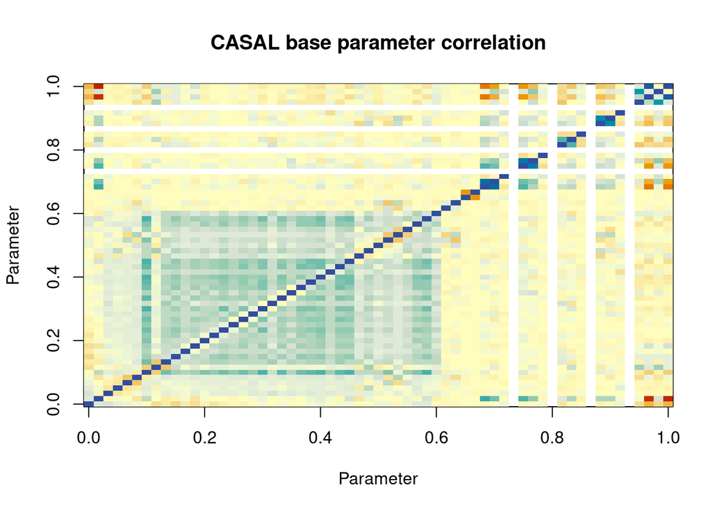

```
## [1] "CASAL base parameter correlation range (excluding 1.0): -0.9193 0.9407"
```

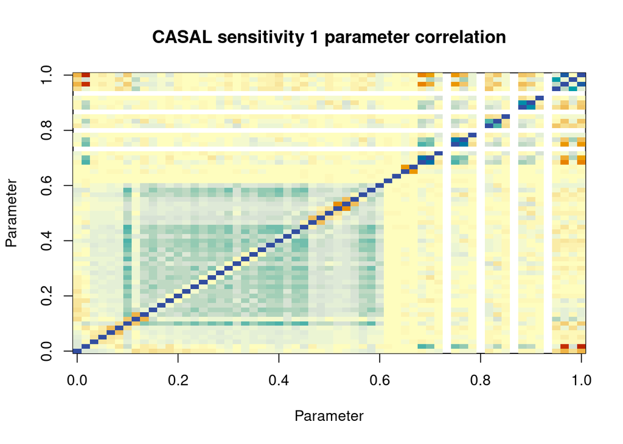

```
## [1] "CASAL sensitivity 1 parameter correlation range (excluding 1.0): -0.9193 0.94"
```

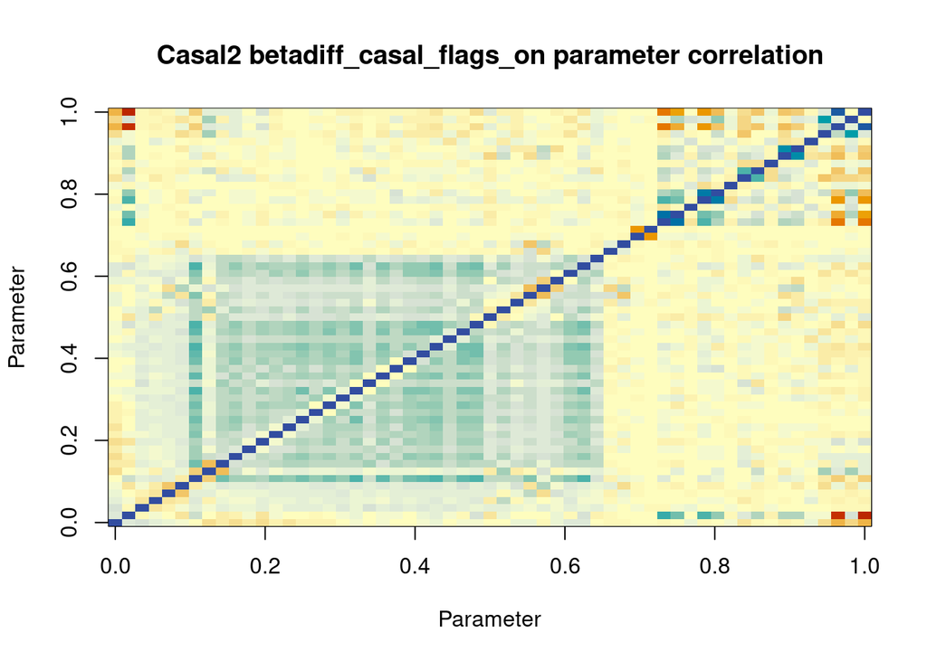

```
## [1] "Casal2 betadiff_casal_flags_on parameter correlation range (excluding 1.0): -0.919151 0.940771"
```

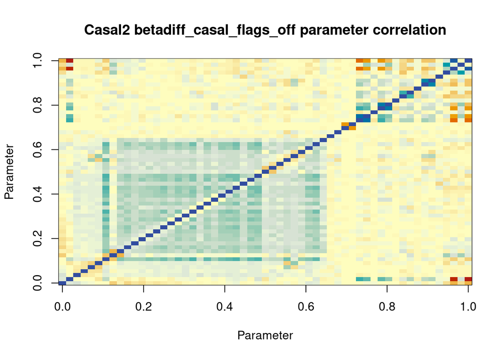

```
## [1] "Casal2 betadiff_casal_flags_off parameter correlation range (excluding 1.0): -0.922937 0.943642"
```

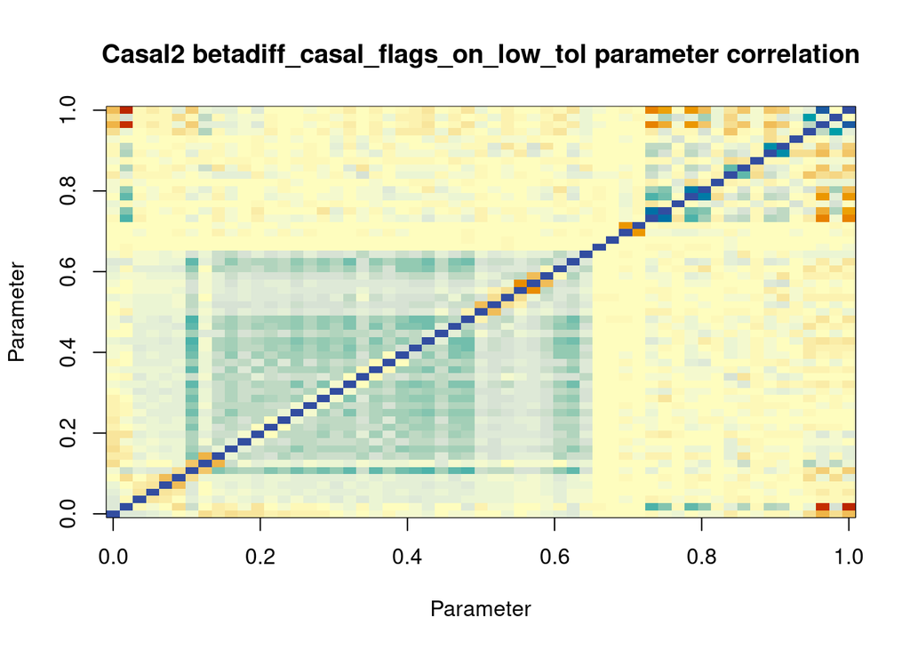

```
## [1] "Casal2 betadiff_casal_flags_on_low_tol parameter correlation range (excluding 1.0): -0.920111 0.939971"
```

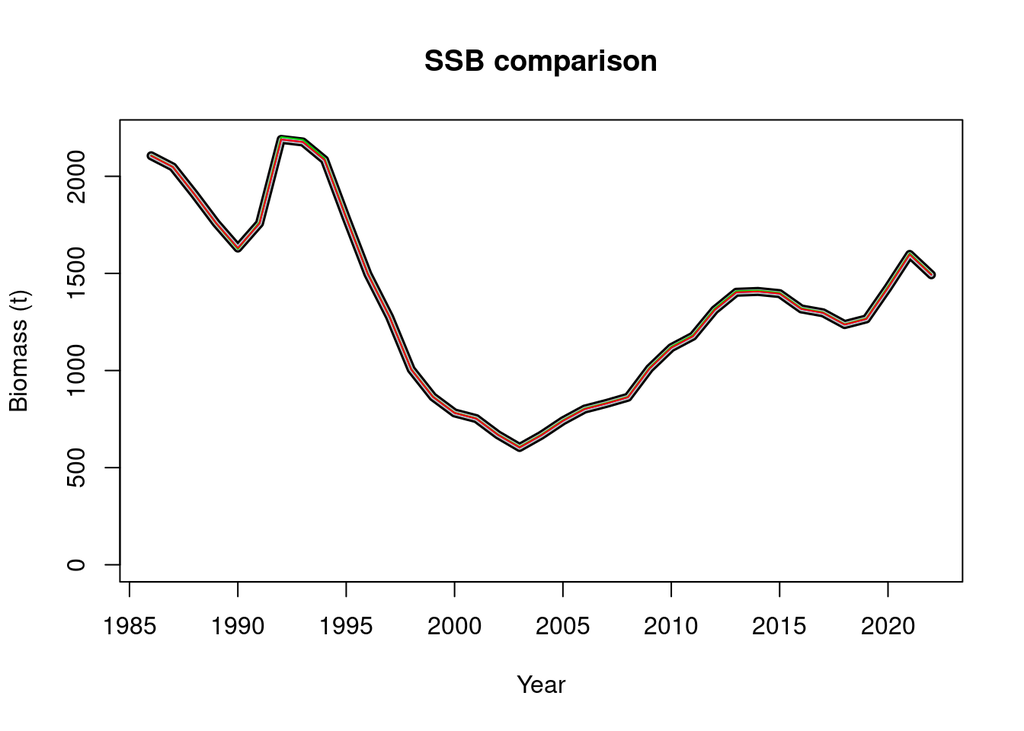

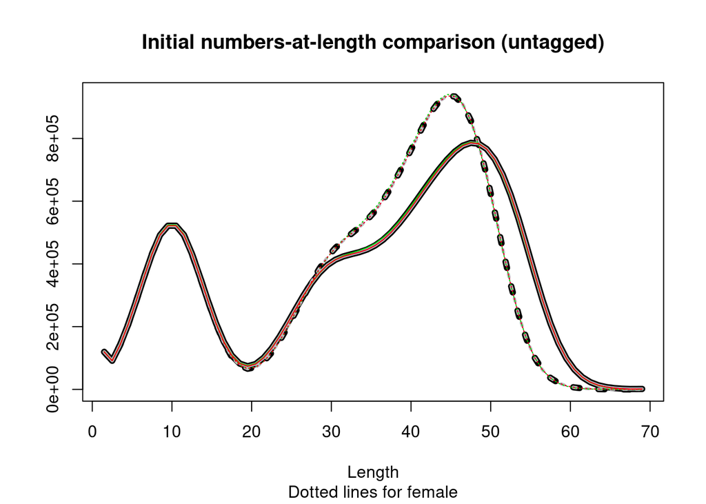

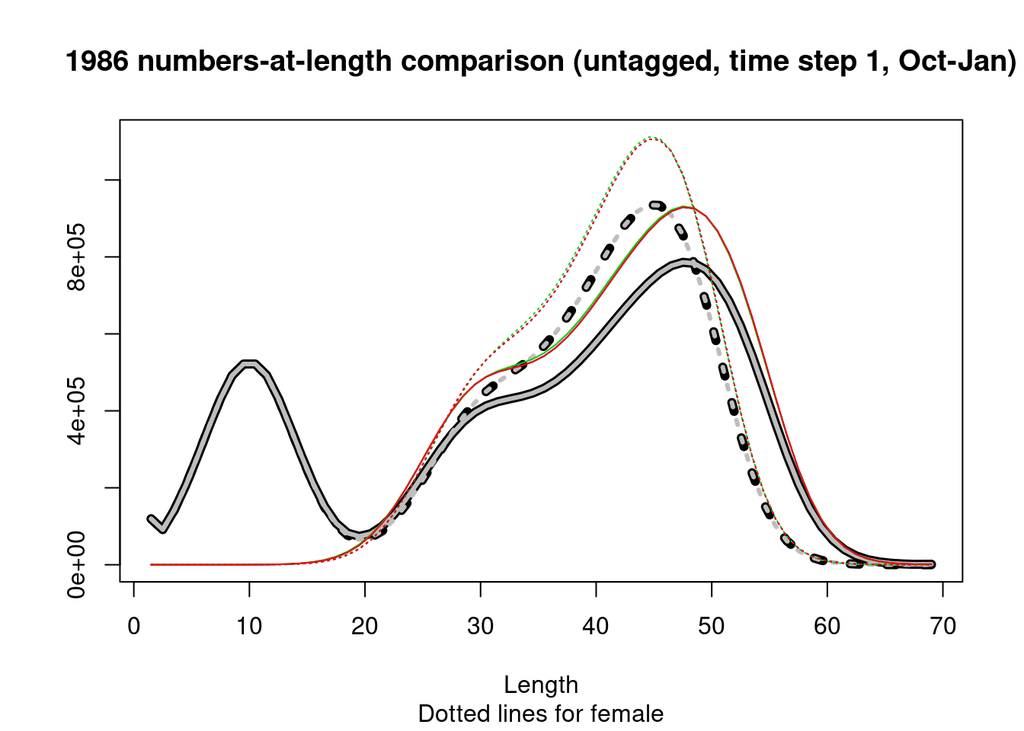

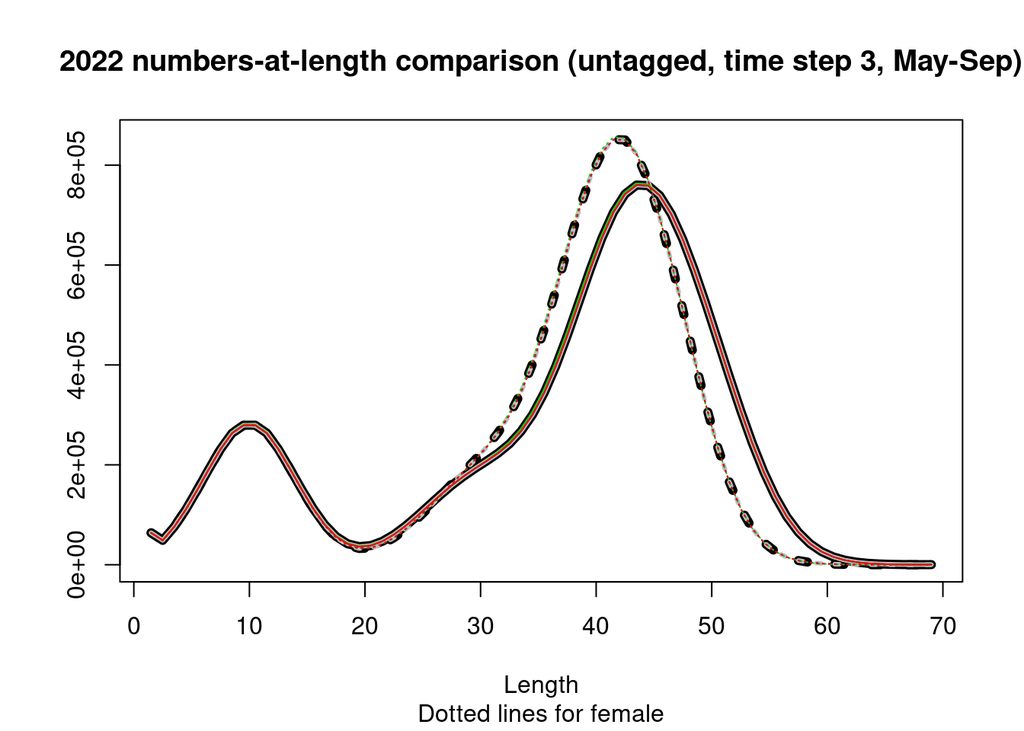

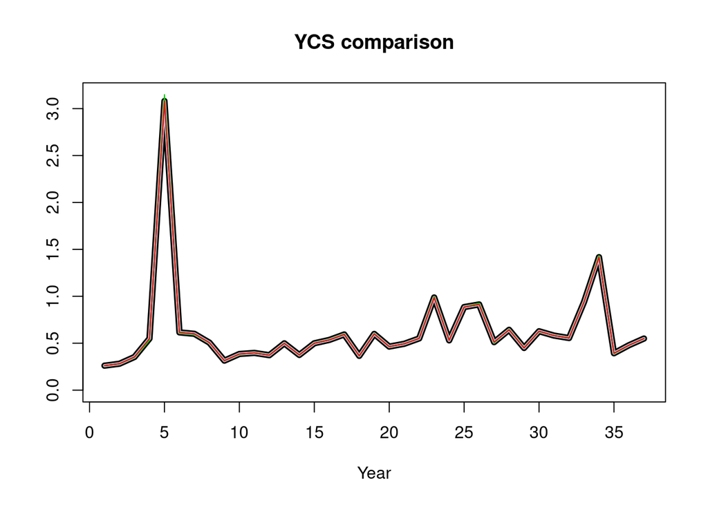

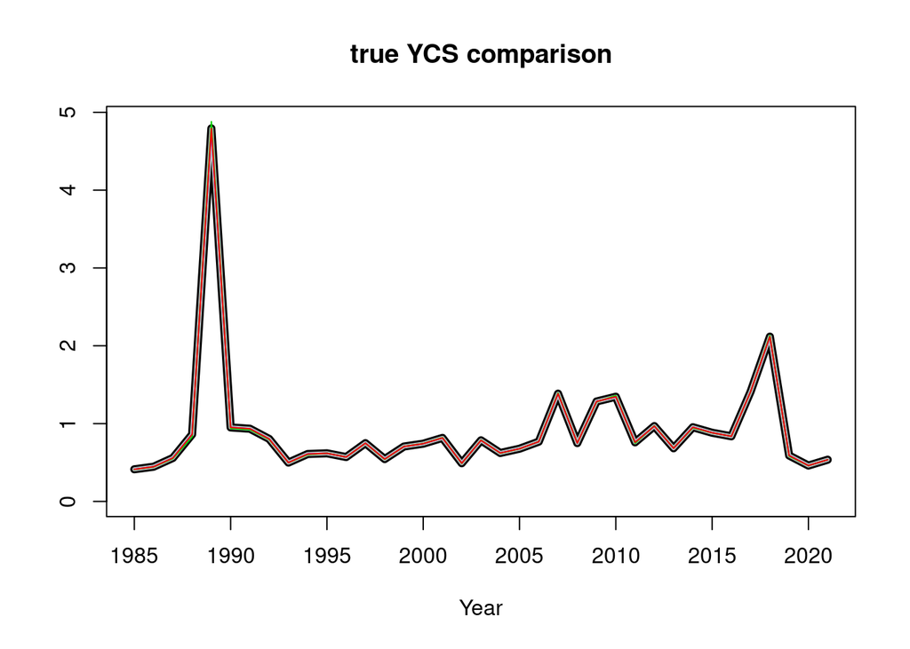

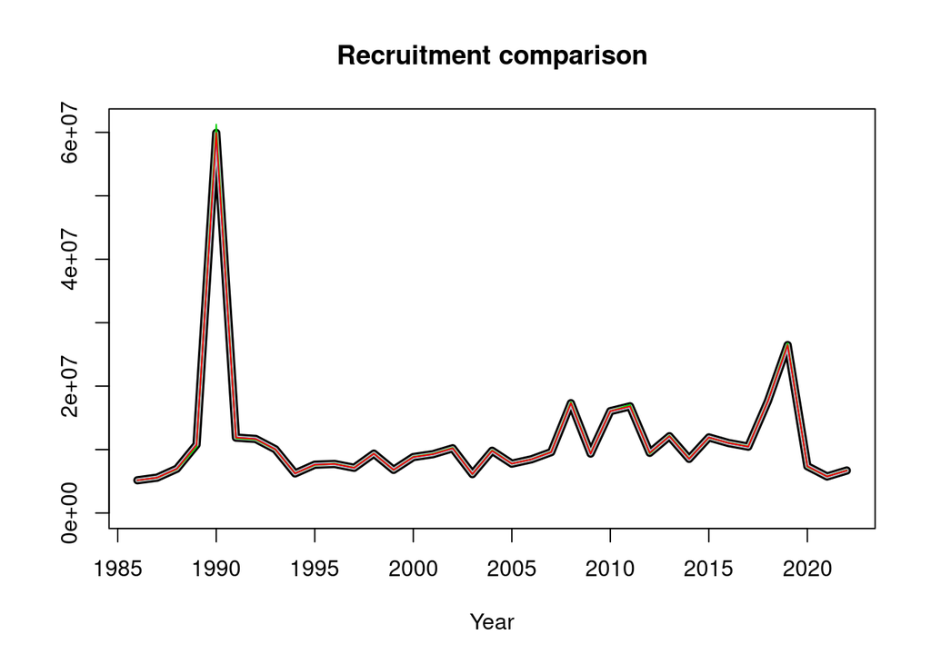

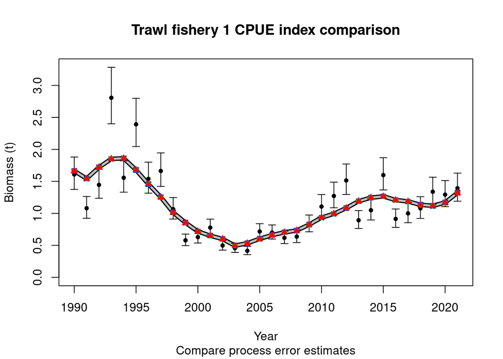

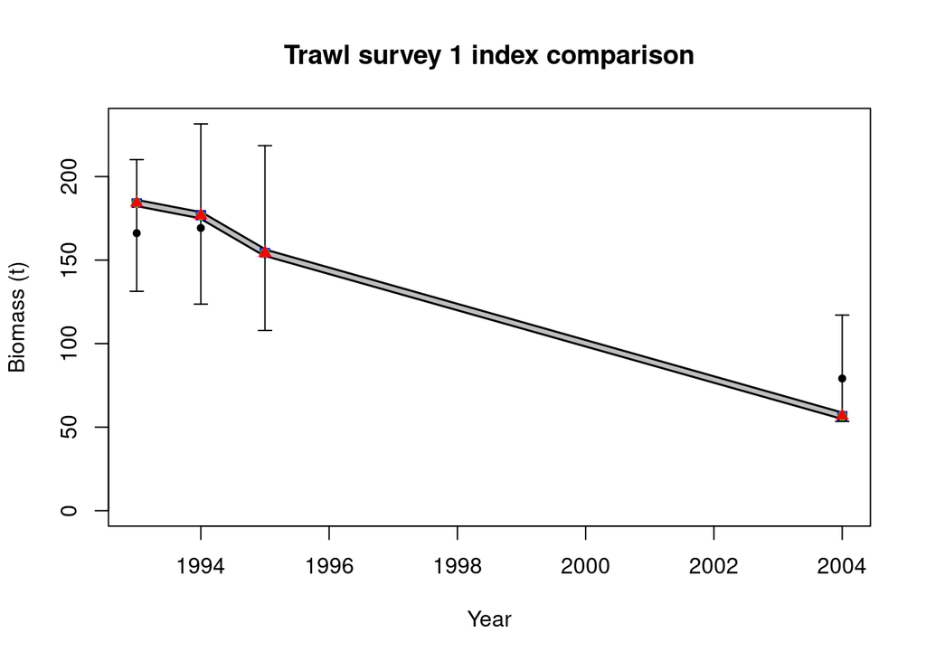

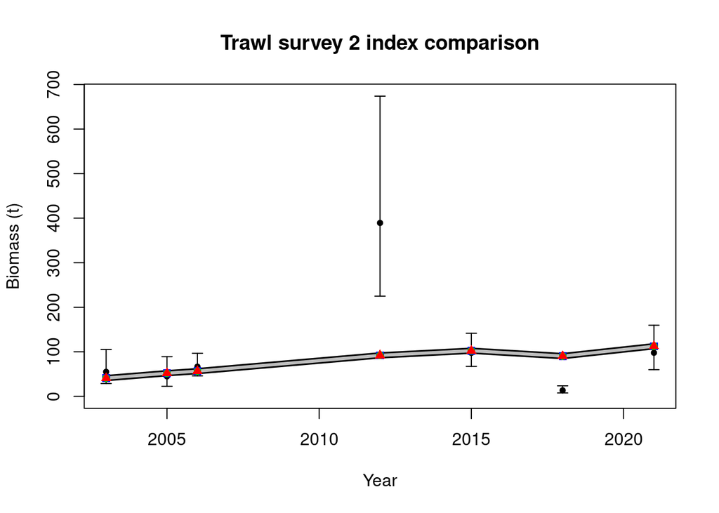

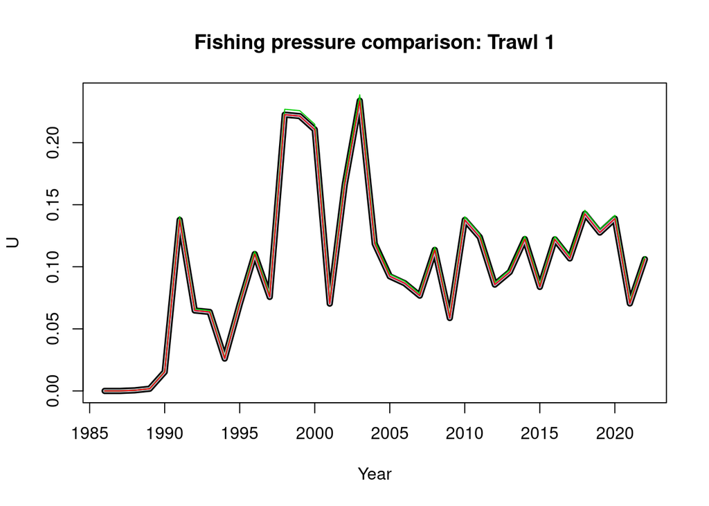

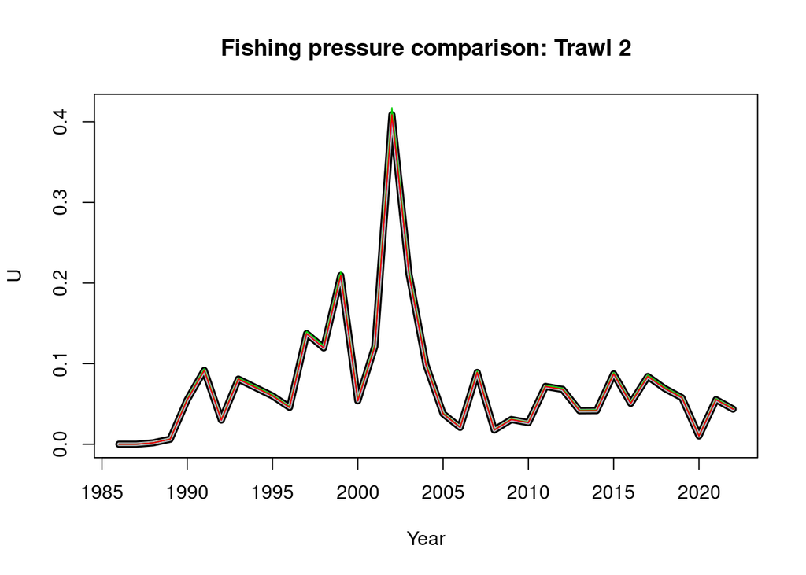

[3 more figures not shown]